# Risk Factor Analysis

## Outcome Variable

**Outcome Variable:** ever_stunted

## Predictor Variables

**Intervention Variable:** meducyrs

**Adjustment Set:**

unadjusted

## Stratifying Variables

The analysis was stratified on these variable(s):

- agecat
- studyid
- country

## Data Summary

| agecat | studyid | country | A | n | nA | nAY0 | nAY1 |
| --- | --- | --- | --- | --- | --- | --- | --- |
| 3 months | ki0047075b-MAL-ED | BANGLADESH | Q4 | 214 | 61 | 50 | 11 |
| 3 months | ki0047075b-MAL-ED | BANGLADESH | Q1 | 214 | 42 | 26 | 16 |
| 3 months | ki0047075b-MAL-ED | BANGLADESH | Q2 | 214 | 28 | 21 | 7 |
| 3 months | ki0047075b-MAL-ED | BANGLADESH | Q3 | 214 | 83 | 56 | 27 |
| 3 months | ki0047075b-MAL-ED | BRAZIL | Q4 | 232 | 79 | 63 | 16 |
| 3 months | ki0047075b-MAL-ED | BRAZIL | Q1 | 232 | 47 | 42 | 5 |
| 3 months | ki0047075b-MAL-ED | BRAZIL | Q2 | 232 | 44 | 35 | 9 |
| 3 months | ki0047075b-MAL-ED | BRAZIL | Q3 | 232 | 62 | 54 | 8 |
| 3 months | ki0047075b-MAL-ED | INDIA | Q4 | 220 | 63 | 50 | 13 |
| 3 months | ki0047075b-MAL-ED | INDIA | Q1 | 220 | 35 | 29 | 6 |
| 3 months | ki0047075b-MAL-ED | INDIA | Q2 | 220 | 52 | 35 | 17 |
| 3 months | ki0047075b-MAL-ED | INDIA | Q3 | 220 | 70 | 50 | 20 |
| 3 months | ki0047075b-MAL-ED | NEPAL | Q4 | 225 | 20 | 16 | 4 |
| 3 months | ki0047075b-MAL-ED | NEPAL | Q1 | 225 | 30 | 25 | 5 |
| 3 months | ki0047075b-MAL-ED | NEPAL | Q2 | 225 | 66 | 52 | 14 |
| 3 months | ki0047075b-MAL-ED | NEPAL | Q3 | 225 | 109 | 97 | 12 |
| 3 months | ki0047075b-MAL-ED | PERU | Q4 | 302 | 91 | 59 | 32 |
| 3 months | ki0047075b-MAL-ED | PERU | Q1 | 302 | 64 | 41 | 23 |
| 3 months | ki0047075b-MAL-ED | PERU | Q2 | 302 | 69 | 44 | 25 |
| 3 months | ki0047075b-MAL-ED | PERU | Q3 | 302 | 78 | 57 | 21 |
| 3 months | ki0047075b-MAL-ED | SOUTH AFRICA | Q4 | 314 | 95 | 70 | 25 |
| 3 months | ki0047075b-MAL-ED | SOUTH AFRICA | Q1 | 314 | 58 | 47 | 11 |
| 3 months | ki0047075b-MAL-ED | SOUTH AFRICA | Q2 | 314 | 92 | 70 | 22 |
| 3 months | ki0047075b-MAL-ED | SOUTH AFRICA | Q3 | 314 | 69 | 45 | 24 |
| 3 months | ki0047075b-MAL-ED | TANZANIA, UNITED REPUBLIC OF | Q4 | 217 | 4 | 4 | 0 |
| 3 months | ki0047075b-MAL-ED | TANZANIA, UNITED REPUBLIC OF | Q1 | 217 | 30 | 19 | 11 |
| 3 months | ki0047075b-MAL-ED | TANZANIA, UNITED REPUBLIC OF | Q2 | 217 | 34 | 25 | 9 |
| 3 months | ki0047075b-MAL-ED | TANZANIA, UNITED REPUBLIC OF | Q3 | 217 | 149 | 103 | 46 |
| 3 months | ki1000108-CMC-V-BCS-2002 | INDIA | Q4 | 362 | 22 | 13 | 9 |
| 3 months | ki1000108-CMC-V-BCS-2002 | INDIA | Q1 | 362 | 100 | 69 | 31 |

[output cut: 462 more lines]

The following strata were considered:

- agecat: 12 months, studyid: ki0047075b-MAL-ED, country: BANGLADESH
- agecat: 12 months, studyid: ki0047075b-MAL-ED, country: BRAZIL
- agecat: 12 months, studyid: ki0047075b-MAL-ED, country: INDIA
- agecat: 12 months, studyid: ki0047075b-MAL-ED, country: NEPAL
- agecat: 12 months, studyid: ki0047075b-MAL-ED, country: PERU
- agecat: 12 months, studyid: ki0047075b-MAL-ED, country: SOUTH AFRICA
- agecat: 12 months, studyid: ki0047075b-MAL-ED, country: TANZANIA, UNITED REPUBLIC OF
- agecat: 12 months, studyid: ki1000108-CMC-V-BCS-2002, country: INDIA
- agecat: 12 months, studyid: ki1000108-IRC, country: INDIA
- agecat: 12 months, studyid: ki1000109-EE, country: PAKISTAN
- agecat: 12 months, studyid: ki1000304b-SAS-CompFeed, country: INDIA
- agecat: 12 months, studyid: ki1000304b-SAS-FoodSuppl, country: INDIA
- agecat: 12 months, studyid: ki1017093-NIH-Birth, country: BANGLADESH
- agecat: 12 months, studyid: ki1017093b-PROVIDE, country: BANGLADESH
- agecat: 12 months, studyid: ki1017093c-NIH-Crypto, country: BANGLADESH
- agecat: 12 months, studyid: ki1066203-TanzaniaChild2, country: TANZANIA, UNITED REPUBLIC OF
- agecat: 12 months, studyid: ki1112895-Guatemala BSC, country: GUATEMALA
- agecat: 12 months, studyid: ki1113344-GMS-Nepal, country: NEPAL
- agecat: 12 months, studyid: ki1119695-PROBIT, country: BELARUS
- agecat: 12 months, studyid: ki1126311-ZVITAMBO, country: ZIMBABWE
- agecat: 12 months, studyid: ki1135781-COHORTS, country: GUATEMALA
- agecat: 12 months, studyid: ki1135781-COHORTS, country: INDIA
- agecat: 12 months, studyid: ki1135781-COHORTS, country: PHILIPPINES
- agecat: 12 months, studyid: ki1148112-LCNI-5, country: MALAWI
- agecat: 12 months, studyid: kiGH5241-JiVitA-3, country: BANGLADESH
- agecat: 12 months, studyid: kiGH5241-JiVitA-4, country: BANGLADESH
- agecat: 18 months, studyid: ki0047075b-MAL-ED, country: BANGLADESH
- agecat: 18 months, studyid: ki0047075b-MAL-ED, country: BRAZIL
- agecat: 18 months, studyid: ki0047075b-MAL-ED, country: INDIA
- agecat: 18 months, studyid: ki0047075b-MAL-ED, country: NEPAL
- agecat: 18 months, studyid: ki0047075b-MAL-ED, country: PERU
- agecat: 18 months, studyid: ki0047075b-MAL-ED, country: SOUTH AFRICA
- agecat: 18 months, studyid: ki0047075b-MAL-ED, country: TANZANIA, UNITED REPUBLIC OF
- agecat: 18 months, studyid: ki1000108-CMC-V-BCS-2002, country: INDIA
- agecat: 18 months, studyid: ki1000108-IRC, country: INDIA
- agecat: 18 months, studyid: ki1000109-EE, country: PAKISTAN
- agecat: 18 months, studyid: ki1000304b-SAS-CompFeed, country: INDIA
- agecat: 18 months, studyid: ki1000304b-SAS-FoodSuppl, country: INDIA
- agecat: 18 months, studyid: ki1017093-NIH-Birth, country: BANGLADESH
- agecat: 18 months, studyid: ki1017093b-PROVIDE, country: BANGLADESH
- agecat: 18 months, studyid: ki1017093c-NIH-Crypto, country: BANGLADESH
- agecat: 18 months, studyid: ki1066203-TanzaniaChild2, country: TANZANIA, UNITED REPUBLIC OF
- agecat: 18 months, studyid: ki1112895-Guatemala BSC, country: GUATEMALA
- agecat: 18 months, studyid: ki1113344-GMS-Nepal, country: NEPAL
- agecat: 18 months, studyid: ki1119695-PROBIT, country: BELARUS
- agecat: 18 months, studyid: ki1126311-ZVITAMBO, country: ZIMBABWE
- agecat: 18 months, studyid: ki1135781-COHORTS, country: GUATEMALA
- agecat: 18 months, studyid: ki1135781-COHORTS, country: PHILIPPINES
- agecat: 18 months, studyid: ki1148112-LCNI-5, country: MALAWI
- agecat: 18 months, studyid: kiGH5241-JiVitA-3, country: BANGLADESH
- agecat: 18 months, studyid: kiGH5241-JiVitA-4, country: BANGLADESH
- agecat: 24 months, studyid: ki0047075b-MAL-ED, country: BANGLADESH
- agecat: 24 months, studyid: ki0047075b-MAL-ED, country: BRAZIL
- agecat: 24 months, studyid: ki0047075b-MAL-ED, country: INDIA
- agecat: 24 months, studyid: ki0047075b-MAL-ED, country: NEPAL
- agecat: 24 months, studyid: ki0047075b-MAL-ED, country: PERU
- agecat: 24 months, studyid: ki0047075b-MAL-ED, country: SOUTH AFRICA
- agecat: 24 months, studyid: ki0047075b-MAL-ED, country: TANZANIA, UNITED REPUBLIC OF
- agecat: 24 months, studyid: ki1000108-CMC-V-BCS-2002, country: INDIA
- agecat: 24 months, studyid: ki1000108-IRC, country: INDIA
- agecat: 24 months, studyid: ki1000109-EE, country: PAKISTAN
- agecat: 24 months, studyid: ki1000304b-SAS-CompFeed, country: INDIA
- agecat: 24 months, studyid: ki1000304b-SAS-FoodSuppl, country: INDIA
- agecat: 24 months, studyid: ki1017093-NIH-Birth, country: BANGLADESH
- agecat: 24 months, studyid: ki1017093b-PROVIDE, country: BANGLADESH
- agecat: 24 months, studyid: ki1017093c-NIH-Crypto, country: BANGLADESH
- agecat: 24 months, studyid: ki1066203-TanzaniaChild2, country: TANZANIA, UNITED REPUBLIC OF
- agecat: 24 months, studyid: ki1113344-GMS-Nepal, country: NEPAL
- agecat: 24 months, studyid: ki1119695-PROBIT, country: BELARUS
- agecat: 24 months, studyid: ki1126311-ZVITAMBO, country: ZIMBABWE
- agecat: 24 months, studyid: ki1135781-COHORTS, country: GUATEMALA
- agecat: 24 months, studyid: ki1135781-COHORTS, country: PHILIPPINES
- agecat: 24 months, studyid: ki1148112-LCNI-5, country: MALAWI
- agecat: 24 months, studyid: kiGH5241-JiVitA-3, country: BANGLADESH
- agecat: 24 months, studyid: kiGH5241-JiVitA-4, country: BANGLADESH
- agecat: 3 months, studyid: ki0047075b-MAL-ED, country: BANGLADESH
- agecat: 3 months, studyid: ki0047075b-MAL-ED, country: BRAZIL
- agecat: 3 months, studyid: ki0047075b-MAL-ED, country: INDIA
- agecat: 3 months, studyid: ki0047075b-MAL-ED, country: NEPAL
- agecat: 3 months, studyid: ki0047075b-MAL-ED, country: PERU
- agecat: 3 months, studyid: ki0047075b-MAL-ED, country: SOUTH AFRICA
- agecat: 3 months, studyid: ki0047075b-MAL-ED, country: TANZANIA, UNITED REPUBLIC OF
- agecat: 3 months, studyid: ki1000108-CMC-V-BCS-2002, country: INDIA
- agecat: 3 months, studyid: ki1000108-IRC, country: INDIA
- agecat: 3 months, studyid: ki1000109-EE, country: PAKISTAN
- agecat: 3 months, studyid: ki1000304b-SAS-CompFeed, country: INDIA
- agecat: 3 months, studyid: ki1017093-NIH-Birth, country: BANGLADESH
- agecat: 3 months, studyid: ki1017093b-PROVIDE, country: BANGLADESH
- agecat: 3 months, studyid: ki1017093c-NIH-Crypto, country: BANGLADESH
- agecat: 3 months, studyid: ki1066203-TanzaniaChild2, country: TANZANIA, UNITED REPUBLIC OF
- agecat: 3 months, studyid: ki1113344-GMS-Nepal, country: NEPAL
- agecat: 3 months, studyid: ki1119695-PROBIT, country: BELARUS
- agecat: 3 months, studyid: ki1126311-ZVITAMBO, country: ZIMBABWE
- agecat: 3 months, studyid: ki1135781-COHORTS, country: GUATEMALA
- agecat: 3 months, studyid: ki1135781-COHORTS, country: INDIA
- agecat: 3 months, studyid: ki1135781-COHORTS, country: PHILIPPINES
- agecat: 3 months, studyid: kiGH5241-JiVitA-3, country: BANGLADESH
- agecat: 3 months, studyid: kiGH5241-JiVitA-4, country: BANGLADESH
- agecat: 6 months, studyid: ki0047075b-MAL-ED, country: BANGLADESH
- agecat: 6 months, studyid: ki0047075b-MAL-ED, country: BRAZIL
- agecat: 6 months, studyid: ki0047075b-MAL-ED, country: INDIA
- agecat: 6 months, studyid: ki0047075b-MAL-ED, country: NEPAL
- agecat: 6 months, studyid: ki0047075b-MAL-ED, country: PERU
- agecat: 6 months, studyid: ki0047075b-MAL-ED, country: SOUTH AFRICA
- agecat: 6 months, studyid: ki0047075b-MAL-ED, country: TANZANIA, UNITED REPUBLIC OF
- agecat: 6 months, studyid: ki1000108-CMC-V-BCS-2002, country: INDIA
- agecat: 6 months, studyid: ki1000108-IRC, country: INDIA
- agecat: 6 months, studyid: ki1000109-EE, country: PAKISTAN
- agecat: 6 months, studyid: ki1000304b-SAS-CompFeed, country: INDIA
- agecat: 6 months, studyid: ki1000304b-SAS-FoodSuppl, country: INDIA
- agecat: 6 months, studyid: ki1017093-NIH-Birth, country: BANGLADESH
- agecat: 6 months, studyid: ki1017093b-PROVIDE, country: BANGLADESH
- agecat: 6 months, studyid: ki1017093c-NIH-Crypto, country: BANGLADESH
- agecat: 6 months, studyid: ki1066203-TanzaniaChild2, country: TANZANIA, UNITED REPUBLIC OF
- agecat: 6 months, studyid: ki1112895-Guatemala BSC, country: GUATEMALA
- agecat: 6 months, studyid: ki1113344-GMS-Nepal, country: NEPAL
- agecat: 6 months, studyid: ki1119695-PROBIT, country: BELARUS
- agecat: 6 months, studyid: ki1126311-ZVITAMBO, country: ZIMBABWE
- agecat: 6 months, studyid: ki1135781-COHORTS, country: GUATEMALA
- agecat: 6 months, studyid: ki1135781-COHORTS, country: PHILIPPINES
- agecat: 6 months, studyid: ki1148112-LCNI-5, country: MALAWI
- agecat: 6 months, studyid: kiGH5241-JiVitA-3, country: BANGLADESH
- agecat: 6 months, studyid: kiGH5241-JiVitA-4, country: BANGLADESH

### Dropped Strata

Some strata were dropped due to rare outcomes:

- agecat: 3 months, studyid: ki0047075b-MAL-ED, country: NEPAL
- agecat: 3 months, studyid: ki0047075b-MAL-ED, country: TANZANIA, UNITED REPUBLIC OF
- agecat: 3 months, studyid: ki1000108-IRC, country: INDIA
- agecat: 3 months, studyid: ki1000109-EE, country: PAKISTAN
- agecat: 3 months, studyid: ki1000304b-SAS-CompFeed, country: INDIA
- agecat: 3 months, studyid: ki1017093b-PROVIDE, country: BANGLADESH
- agecat: 3 months, studyid: ki1066203-TanzaniaChild2, country: TANZANIA, UNITED REPUBLIC OF
- agecat: 3 months, studyid: ki1113344-GMS-Nepal, country: NEPAL
- agecat: 3 months, studyid: ki1119695-PROBIT, country: BELARUS
- agecat: 3 months, studyid: ki1135781-COHORTS, country: GUATEMALA
- agecat: 3 months, studyid: kiGH5241-JiVitA-4, country: BANGLADESH
- agecat: 6 months, studyid: ki0047075b-MAL-ED, country: TANZANIA, UNITED REPUBLIC OF
- agecat: 6 months, studyid: ki1000109-EE, country: PAKISTAN
- agecat: 6 months, studyid: ki1000304b-SAS-CompFeed, country: INDIA
- agecat: 6 months, studyid: ki1000304b-SAS-FoodSuppl, country: INDIA
- agecat: 6 months, studyid: ki1017093b-PROVIDE, country: BANGLADESH
- agecat: 6 months, studyid: ki1066203-TanzaniaChild2, country: TANZANIA, UNITED REPUBLIC OF
- agecat: 6 months, studyid: ki1119695-PROBIT, country: BELARUS
- agecat: 6 months, studyid: ki1135781-COHORTS, country: GUATEMALA
- agecat: 6 months, studyid: ki1148112-LCNI-5, country: MALAWI
- agecat: 6 months, studyid: kiGH5241-JiVitA-4, country: BANGLADESH
- agecat: 12 months, studyid: ki0047075b-MAL-ED, country: TANZANIA, UNITED REPUBLIC OF
- agecat: 12 months, studyid: ki1000109-EE, country: PAKISTAN
- agecat: 12 months, studyid: ki1000304b-SAS-CompFeed, country: INDIA
- agecat: 12 months, studyid: ki1000304b-SAS-FoodSuppl, country: INDIA
- agecat: 12 months, studyid: ki1017093b-PROVIDE, country: BANGLADESH
- agecat: 12 months, studyid: ki1066203-TanzaniaChild2, country: TANZANIA, UNITED REPUBLIC OF
- agecat: 12 months, studyid: ki1119695-PROBIT, country: BELARUS
- agecat: 12 months, studyid: ki1135781-COHORTS, country: GUATEMALA
- agecat: 12 months, studyid: ki1148112-LCNI-5, country: MALAWI
- agecat: 12 months, studyid: kiGH5241-JiVitA-4, country: BANGLADESH
- agecat: 18 months, studyid: ki0047075b-MAL-ED, country: TANZANIA, UNITED REPUBLIC OF
- agecat: 18 months, studyid: ki1000109-EE, country: PAKISTAN
- agecat: 18 months, studyid: ki1000304b-SAS-CompFeed, country: INDIA
- agecat: 18 months, studyid: ki1000304b-SAS-FoodSuppl, country: INDIA
- agecat: 18 months, studyid: ki1017093b-PROVIDE, country: BANGLADESH
- agecat: 18 months, studyid: ki1066203-TanzaniaChild2, country: TANZANIA, UNITED REPUBLIC OF
- agecat: 18 months, studyid: ki1119695-PROBIT, country: BELARUS
- agecat: 18 months, studyid: ki1135781-COHORTS, country: GUATEMALA
- agecat: 18 months, studyid: ki1148112-LCNI-5, country: MALAWI
- agecat: 18 months, studyid: kiGH5241-JiVitA-4, country: BANGLADESH
- agecat: 24 months, studyid: ki0047075b-MAL-ED, country: TANZANIA, UNITED REPUBLIC OF
- agecat: 24 months, studyid: ki1000108-CMC-V-BCS-2002, country: INDIA
- agecat: 24 months, studyid: ki1000109-EE, country: PAKISTAN
- agecat: 24 months, studyid: ki1000304b-SAS-CompFeed, country: INDIA
- agecat: 24 months, studyid: ki1000304b-SAS-FoodSuppl, country: INDIA
- agecat: 24 months, studyid: ki1017093b-PROVIDE, country: BANGLADESH
- agecat: 24 months, studyid: ki1066203-TanzaniaChild2, country: TANZANIA, UNITED REPUBLIC OF
- agecat: 24 months, studyid: ki1119695-PROBIT, country: BELARUS
- agecat: 24 months, studyid: ki1135781-COHORTS, country: GUATEMALA
- agecat: 24 months, studyid: ki1148112-LCNI-5, country: MALAWI
- agecat: 24 months, studyid: kiGH5241-JiVitA-3, country: BANGLADESH
- agecat: 24 months, studyid: kiGH5241-JiVitA-4, country: BANGLADESH

## Methods Detail

We’re interested in the causal parameters $E[Y_a]$ for all values of $a \in \mathcal{A}$. These parameters represent the mean outcome if, possibly contrary to fact, we intervened to set all units to have $A=a$. Under the randomization and positivity assumptions, these are identified by the statistical parameters $\psi_a=E_W[E_{Y|A,W}(Y|A=a,W)]$. In addition, we’re interested in the mean of $Y$, $E[Y]$ under no intervention (the observed mean). We will estimate these parameters by using SuperLearner to fit the relevant likelihood factors – $E_{Y|A,W}(Y|A=a,W)$ and $p(A=a|W)$, and then updating our likelihood fit using a joint TMLE.

For unadjusted analyses ($W=\{\}$), initial likelihoods were estimated using Lrnr_glm to estimate the simple $E(Y|A)$ and Lrnr_mean to estimate $p(A)$. For adjusted analyses, a small library containing Lrnr_glmnet, Lrnr_xgboost, and Lrnr_mean was used.

Having estimated these parameters, we will then use the delta method to estimate relative risks and attributable risks relative to a prespecified baseline level of $A$.

# Results Detail

## Results Plots

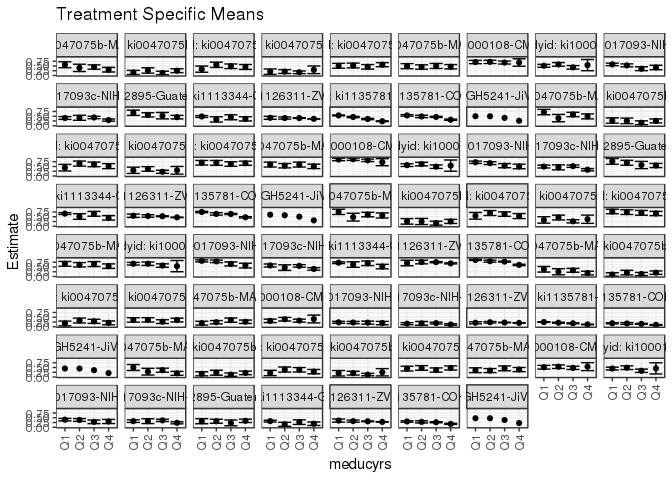

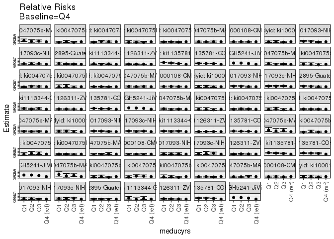

[figure not shown]

[figure not shown]

## Results Table

### Parameter: TSM

| agecat | studyid | country | intervention_level | baseline_level | estimate | ci_lower | ci_upper |
| --- | --- | --- | --- | --- | --- | --- | --- |
| 3 months | ki0047075b-MAL-ED | BANGLADESH | Q4 | NA | 0.1803279 | 0.0836222 | 0.2770335 |
| 3 months | ki0047075b-MAL-ED | BANGLADESH | Q1 | NA | 0.3809524 | 0.2337422 | 0.5281626 |
| 3 months | ki0047075b-MAL-ED | BANGLADESH | Q2 | NA | 0.2500000 | 0.0892367 | 0.4107633 |
| 3 months | ki0047075b-MAL-ED | BANGLADESH | Q3 | NA | 0.3253012 | 0.2242774 | 0.4263251 |
| 3 months | ki0047075b-MAL-ED | BRAZIL | Q4 | NA | 0.2025316 | 0.1137188 | 0.2913445 |
| 3 months | ki0047075b-MAL-ED | BRAZIL | Q1 | NA | 0.1063830 | 0.0180447 | 0.1947213 |
| 3 months | ki0047075b-MAL-ED | BRAZIL | Q2 | NA | 0.2045455 | 0.0851020 | 0.3239889 |
| 3 months | ki0047075b-MAL-ED | BRAZIL | Q3 | NA | 0.1290323 | 0.0454064 | 0.2126581 |
| 3 months | ki0047075b-MAL-ED | INDIA | Q4 | NA | 0.2063492 | 0.1061918 | 0.3065066 |
| 3 months | ki0047075b-MAL-ED | INDIA | Q1 | NA | 0.1714286 | 0.0462846 | 0.2965725 |
| 3 months | ki0047075b-MAL-ED | INDIA | Q2 | NA | 0.3269231 | 0.1991349 | 0.4547113 |
| 3 months | ki0047075b-MAL-ED | INDIA | Q3 | NA | 0.2857143 | 0.1796448 | 0.3917837 |
| 3 months | ki0047075b-MAL-ED | PERU | Q4 | NA | 0.3516484 | 0.2533815 | 0.4499152 |
| 3 months | ki0047075b-MAL-ED | PERU | Q1 | NA | 0.3593750 | 0.2416268 | 0.4771232 |
| 3 months | ki0047075b-MAL-ED | PERU | Q2 | NA | 0.3623188 | 0.2487155 | 0.4759222 |
| 3 months | ki0047075b-MAL-ED | PERU | Q3 | NA | 0.2692308 | 0.1706315 | 0.3678300 |
| 3 months | ki0047075b-MAL-ED | SOUTH AFRICA | Q4 | NA | 0.2631579 | 0.1744680 | 0.3518478 |
| 3 months | ki0047075b-MAL-ED | SOUTH AFRICA | Q1 | NA | 0.1896552 | 0.0886034 | 0.2907070 |
| 3 months | ki0047075b-MAL-ED | SOUTH AFRICA | Q2 | NA | 0.2391304 | 0.1518294 | 0.3264315 |
| 3 months | ki0047075b-MAL-ED | SOUTH AFRICA | Q3 | NA | 0.3478261 | 0.2352674 | 0.4603848 |
| 3 months | ki1000108-CMC-V-BCS-2002 | INDIA | Q4 | NA | 0.4090909 | 0.2033561 | 0.6148257 |
| 3 months | ki1000108-CMC-V-BCS-2002 | INDIA | Q1 | NA | 0.3100000 | 0.2192275 | 0.4007725 |
| 3 months | ki1000108-CMC-V-BCS-2002 | INDIA | Q2 | NA | 0.3962264 | 0.3029859 | 0.4894669 |
| 3 months | ki1000108-CMC-V-BCS-2002 | INDIA | Q3 | NA | 0.3208955 | 0.2417463 | 0.4000447 |
| 3 months | ki1017093-NIH-Birth | BANGLADESH | Q4 | NA | 0.1948052 | 0.1062735 | 0.2833369 |
| 3 months | ki1017093-NIH-Birth | BANGLADESH | Q1 | NA | 0.2334630 | 0.1817020 | 0.2852240 |
| 3 months | ki1017093-NIH-Birth | BANGLADESH | Q2 | NA | 0.2227979 | 0.1640439 | 0.2815519 |
| 3 months | ki1017093-NIH-Birth | BANGLADESH | Q3 | NA | 0.2156863 | 0.1358041 | 0.2955684 |
| 3 months | ki1017093c-NIH-Crypto | BANGLADESH | Q4 | NA | 0.1181102 | 0.0783939 | 0.1578265 |
| 3 months | ki1017093c-NIH-Crypto | BANGLADESH | Q1 | NA | 0.1612903 | 0.1083985 | 0.2141821 |

[output cut: 250 more lines]

### Parameter: E(Y)

| agecat | studyid | country | intervention_level | baseline_level | estimate | ci_lower | ci_upper |
| --- | --- | --- | --- | --- | --- | --- | --- |
| 3 months | ki0047075b-MAL-ED | BANGLADESH | NA | NA | 0.2850467 | 0.2244213 | 0.3456722 |
| 3 months | ki0047075b-MAL-ED | BRAZIL | NA | NA | 0.1637931 | 0.1160680 | 0.2115182 |
| 3 months | ki0047075b-MAL-ED | INDIA | NA | NA | 0.2545455 | 0.1968530 | 0.3122379 |
| 3 months | ki0047075b-MAL-ED | PERU | NA | NA | 0.3344371 | 0.2811384 | 0.3877358 |
| 3 months | ki0047075b-MAL-ED | SOUTH AFRICA | NA | NA | 0.2611465 | 0.2124837 | 0.3098093 |
| 3 months | ki1000108-CMC-V-BCS-2002 | INDIA | NA | NA | 0.3453039 | 0.2962566 | 0.3943512 |
| 3 months | ki1017093-NIH-Birth | BANGLADESH | NA | NA | 0.2225755 | 0.1900416 | 0.2551094 |
| 3 months | ki1017093c-NIH-Crypto | BANGLADESH | NA | NA | 0.1596306 | 0.1335394 | 0.1857218 |
| 3 months | ki1126311-ZVITAMBO | ZIMBABWE | NA | NA | 0.2095496 | 0.2028104 | 0.2162889 |
| 3 months | ki1135781-COHORTS | INDIA | NA | NA | 0.1884493 | 0.1782621 | 0.1986366 |
| 3 months | ki1135781-COHORTS | PHILIPPINES | NA | NA | 0.1446335 | 0.1321610 | 0.1571060 |
| 3 months | kiGH5241-JiVitA-3 | BANGLADESH | NA | NA | 0.4033865 | NA | NA |
| 6 months | ki0047075b-MAL-ED | BANGLADESH | NA | NA | 0.3300000 | 0.2646695 | 0.3953305 |
| 6 months | ki0047075b-MAL-ED | BRAZIL | NA | NA | 0.1843318 | 0.1326214 | 0.2360422 |
| 6 months | ki0047075b-MAL-ED | INDIA | NA | NA | 0.3285714 | 0.2648934 | 0.3922495 |
| 6 months | ki0047075b-MAL-ED | NEPAL | NA | NA | 0.1704036 | 0.1209447 | 0.2198625 |
| 6 months | ki0047075b-MAL-ED | PERU | NA | NA | 0.4412811 | 0.3831213 | 0.4994410 |
| 6 months | ki0047075b-MAL-ED | SOUTH AFRICA | NA | NA | 0.3837638 | 0.3257580 | 0.4417697 |
| 6 months | ki1000108-CMC-V-BCS-2002 | INDIA | NA | NA | 0.5122616 | 0.4610525 | 0.5634707 |
| 6 months | ki1000108-IRC | INDIA | NA | NA | 0.4240196 | 0.3760078 | 0.4720314 |
| 6 months | ki1017093-NIH-Birth | BANGLADESH | NA | NA | 0.3647913 | 0.3245616 | 0.4050210 |
| 6 months | ki1017093c-NIH-Crypto | BANGLADESH | NA | NA | 0.3070652 | 0.2737175 | 0.3404129 |
| 6 months | ki1112895-Guatemala BSC | GUATEMALA | NA | NA | 0.3169811 | 0.2608532 | 0.3731091 |
| 6 months | ki1113344-GMS-Nepal | NEPAL | NA | NA | 0.2872340 | 0.2498587 | 0.3246094 |
| 6 months | ki1126311-ZVITAMBO | ZIMBABWE | NA | NA | 0.2946743 | 0.2853008 | 0.3040478 |
| 6 months | ki1135781-COHORTS | PHILIPPINES | NA | NA | 0.2498218 | 0.2338012 | 0.2658424 |
| 6 months | kiGH5241-JiVitA-3 | BANGLADESH | NA | NA | 0.4254875 | NA | NA |
| 12 months | ki0047075b-MAL-ED | BANGLADESH | NA | NA | 0.4226804 | 0.3529883 | 0.4923725 |
| 12 months | ki0047075b-MAL-ED | BRAZIL | NA | NA | 0.2038835 | 0.1487329 | 0.2590341 |
| 12 months | ki0047075b-MAL-ED | INDIA | NA | NA | 0.4685990 | 0.4004552 | 0.5367428 |
| 12 months | ki0047075b-MAL-ED | NEPAL | NA | NA | 0.1954545 | 0.1429346 | 0.2479745 |
| 12 months | ki0047075b-MAL-ED | PERU | NA | NA | 0.5167286 | 0.4569002 | 0.5765570 |
| 12 months | ki0047075b-MAL-ED | SOUTH AFRICA | NA | NA | 0.4710425 | 0.4101339 | 0.5319511 |
| 12 months | ki1000108-CMC-V-BCS-2002 | INDIA | NA | NA | 0.6989247 | 0.6522466 | 0.7456029 |
| 12 months | ki1000108-IRC | INDIA | NA | NA | 0.5073529 | 0.4587823 | 0.5559236 |
| 12 months | ki1017093-NIH-Birth | BANGLADESH | NA | NA | 0.5101664 | 0.4680034 | 0.5523294 |
| 12 months | ki1017093c-NIH-Crypto | BANGLADESH | NA | NA | 0.3799726 | 0.3447141 | 0.4152311 |
| 12 months | ki1112895-Guatemala BSC | GUATEMALA | NA | NA | 0.5338346 | 0.4737728 | 0.5938964 |
| 12 months | ki1113344-GMS-Nepal | NEPAL | NA | NA | 0.4559585 | 0.4153551 | 0.4965620 |
| 12 months | ki1126311-ZVITAMBO | ZIMBABWE | NA | NA | 0.3772120 | 0.3677924 | 0.3866315 |
| 12 months | ki1135781-COHORTS | INDIA | NA | NA | 0.3927790 | 0.3798523 | 0.4057057 |
| 12 months | ki1135781-COHORTS | PHILIPPINES | NA | NA | 0.4388125 | 0.4203024 | 0.4573225 |
| 12 months | kiGH5241-JiVitA-3 | BANGLADESH | NA | NA | 0.4517093 | NA | NA |
| 18 months | ki0047075b-MAL-ED | BANGLADESH | NA | NA | 0.5631579 | 0.4924457 | 0.6338701 |
| 18 months | ki0047075b-MAL-ED | BRAZIL | NA | NA | 0.2331606 | 0.1733501 | 0.2929711 |
| 18 months | ki0047075b-MAL-ED | INDIA | NA | NA | 0.5671642 | 0.4984970 | 0.6358313 |
| 18 months | ki0047075b-MAL-ED | NEPAL | NA | NA | 0.2824074 | 0.2222338 | 0.3425810 |
| 18 months | ki0047075b-MAL-ED | PERU | NA | NA | 0.6707819 | 0.6115749 | 0.7299889 |
| 18 months | ki0047075b-MAL-ED | SOUTH AFRICA | NA | NA | 0.5573123 | 0.4959861 | 0.6186384 |
| 18 months | ki1000108-CMC-V-BCS-2002 | INDIA | NA | NA | 0.8471850 | 0.8106214 | 0.8837486 |
| 18 months | ki1000108-IRC | INDIA | NA | NA | 0.5623472 | 0.5142095 | 0.6104849 |
| 18 months | ki1017093-NIH-Birth | BANGLADESH | NA | NA | 0.6498994 | 0.6079209 | 0.6918779 |
| 18 months | ki1017093c-NIH-Crypto | BANGLADESH | NA | NA | 0.4433566 | 0.4069178 | 0.4797954 |
| 18 months | ki1112895-Guatemala BSC | GUATEMALA | NA | NA | 0.6270270 | 0.5571522 | 0.6969019 |
| 18 months | ki1113344-GMS-Nepal | NEPAL | NA | NA | 0.6252189 | 0.5854800 | 0.6649578 |
| 18 months | ki1126311-ZVITAMBO | ZIMBABWE | NA | NA | 0.4912040 | 0.4797162 | 0.5026917 |
| 18 months | ki1135781-COHORTS | PHILIPPINES | NA | NA | 0.6166413 | 0.5980630 | 0.6352197 |
| 18 months | kiGH5241-JiVitA-3 | BANGLADESH | NA | NA | 0.5434189 | NA | NA |
| 24 months | ki0047075b-MAL-ED | BANGLADESH | NA | NA | 0.6123596 | 0.5405836 | 0.6841356 |
| 24 months | ki0047075b-MAL-ED | BRAZIL | NA | NA | 0.2285714 | 0.1661789 | 0.2909639 |
| 24 months | ki0047075b-MAL-ED | INDIA | NA | NA | 0.6100000 | 0.5422329 | 0.6777671 |
| 24 months | ki0047075b-MAL-ED | NEPAL | NA | NA | 0.3364486 | 0.2729952 | 0.3999020 |
| 24 months | ki0047075b-MAL-ED | PERU | NA | NA | 0.7188940 | 0.6589441 | 0.7788439 |
| 24 months | ki0047075b-MAL-ED | SOUTH AFRICA | NA | NA | 0.6157025 | 0.5542897 | 0.6771153 |
| 24 months | ki1000108-IRC | INDIA | NA | NA | 0.6414634 | 0.5949863 | 0.6879405 |
| 24 months | ki1017093-NIH-Birth | BANGLADESH | NA | NA | 0.7553191 | 0.7164122 | 0.7942261 |
| 24 months | ki1017093c-NIH-Crypto | BANGLADESH | NA | NA | 0.5015773 | 0.4626267 | 0.5405279 |
| 24 months | ki1113344-GMS-Nepal | NEPAL | NA | NA | 0.6902655 | 0.6521052 | 0.7284258 |
| 24 months | ki1126311-ZVITAMBO | ZIMBABWE | NA | NA | 0.7163385 | 0.6959512 | 0.7367258 |
| 24 months | ki1135781-COHORTS | PHILIPPINES | NA | NA | 0.7525371 | 0.7358238 | 0.7692504 |

### Parameter: RR

| agecat | studyid | country | intervention_level | baseline_level | estimate | ci_lower | ci_upper |
| --- | --- | --- | --- | --- | --- | --- | --- |
| 3 months | ki0047075b-MAL-ED | BANGLADESH | Q4 | Q4 | 1.0000000 | 1.0000000 | 1.000000 |
| 3 months | ki0047075b-MAL-ED | BANGLADESH | Q1 | Q4 | 2.1125541 | 1.0907873 | 4.091435 |
| 3 months | ki0047075b-MAL-ED | BANGLADESH | Q2 | Q4 | 1.3863636 | 0.6001121 | 3.202742 |
| 3 months | ki0047075b-MAL-ED | BANGLADESH | Q3 | Q4 | 1.8039430 | 0.9707053 | 3.352419 |
| 3 months | ki0047075b-MAL-ED | BRAZIL | Q4 | Q4 | 1.0000000 | 1.0000000 | 1.000000 |
| 3 months | ki0047075b-MAL-ED | BRAZIL | Q1 | Q4 | 0.5252660 | 0.2053775 | 1.343401 |
| 3 months | ki0047075b-MAL-ED | BRAZIL | Q2 | Q4 | 1.0099432 | 0.4865719 | 2.096268 |
| 3 months | ki0047075b-MAL-ED | BRAZIL | Q3 | Q4 | 0.6370968 | 0.2913158 | 1.393307 |
| 3 months | ki0047075b-MAL-ED | INDIA | Q4 | Q4 | 1.0000000 | 1.0000000 | 1.000000 |
| 3 months | ki0047075b-MAL-ED | INDIA | Q1 | Q4 | 0.8307692 | 0.3457479 | 1.996187 |
| 3 months | ki0047075b-MAL-ED | INDIA | Q2 | Q4 | 1.5843195 | 0.8495513 | 2.954581 |
| 3 months | ki0047075b-MAL-ED | INDIA | Q3 | Q4 | 1.3846154 | 0.7515231 | 2.551032 |
| 3 months | ki0047075b-MAL-ED | PERU | Q4 | Q4 | 1.0000000 | 1.0000000 | 1.000000 |
| 3 months | ki0047075b-MAL-ED | PERU | Q1 | Q4 | 1.0219727 | 0.6643832 | 1.572027 |
| 3 months | ki0047075b-MAL-ED | PERU | Q2 | Q4 | 1.0303442 | 0.6769837 | 1.568146 |
| 3 months | ki0047075b-MAL-ED | PERU | Q3 | Q4 | 0.7656250 | 0.4830056 | 1.213613 |
| 3 months | ki0047075b-MAL-ED | SOUTH AFRICA | Q4 | Q4 | 1.0000000 | 1.0000000 | 1.000000 |
| 3 months | ki0047075b-MAL-ED | SOUTH AFRICA | Q1 | Q4 | 0.7206897 | 0.3836570 | 1.353797 |
| 3 months | ki0047075b-MAL-ED | SOUTH AFRICA | Q2 | Q4 | 0.9086957 | 0.5528879 | 1.493481 |
| 3 months | ki0047075b-MAL-ED | SOUTH AFRICA | Q3 | Q4 | 1.3217391 | 0.8283807 | 2.108927 |
| 3 months | ki1000108-CMC-V-BCS-2002 | INDIA | Q4 | Q4 | 1.0000000 | 1.0000000 | 1.000000 |
| 3 months | ki1000108-CMC-V-BCS-2002 | INDIA | Q1 | Q4 | 0.7577778 | 0.4234556 | 1.356051 |
| 3 months | ki1000108-CMC-V-BCS-2002 | INDIA | Q2 | Q4 | 0.9685535 | 0.5558861 | 1.687568 |
| 3 months | ki1000108-CMC-V-BCS-2002 | INDIA | Q3 | Q4 | 0.7844113 | 0.4480019 | 1.373434 |
| 3 months | ki1017093-NIH-Birth | BANGLADESH | Q4 | Q4 | 1.0000000 | 1.0000000 | 1.000000 |
| 3 months | ki1017093-NIH-Birth | BANGLADESH | Q1 | Q4 | 1.1984436 | 0.7227904 | 1.987114 |
| 3 months | ki1017093-NIH-Birth | BANGLADESH | Q2 | Q4 | 1.1436960 | 0.6762669 | 1.934208 |
| 3 months | ki1017093-NIH-Birth | BANGLADESH | Q3 | Q4 | 1.1071895 | 0.6160429 | 1.989908 |
| 3 months | ki1017093c-NIH-Crypto | BANGLADESH | Q4 | Q4 | 1.0000000 | 1.0000000 | 1.000000 |
| 3 months | ki1017093c-NIH-Crypto | BANGLADESH | Q1 | Q4 | 1.3655914 | 0.8537599 | 2.184267 |

[output cut: 250 more lines]

### Parameter: PAR

| agecat | studyid | country | intervention_level | baseline_level | estimate | ci_lower | ci_upper |
| --- | --- | --- | --- | --- | --- | --- | --- |
| 3 months | ki0047075b-MAL-ED | BANGLADESH | Q4 | NA | 0.1047189 | 0.0169924 | 0.1924453 |
| 3 months | ki0047075b-MAL-ED | BRAZIL | Q4 | NA | -0.0387385 | -0.1079743 | 0.0304973 |
| 3 months | ki0047075b-MAL-ED | INDIA | Q4 | NA | 0.0481962 | -0.0390655 | 0.1354580 |
| 3 months | ki0047075b-MAL-ED | PERU | Q4 | NA | -0.0172113 | -0.0989286 | 0.0645061 |
| 3 months | ki0047075b-MAL-ED | SOUTH AFRICA | Q4 | NA | -0.0020114 | -0.0760003 | 0.0719775 |
| 3 months | ki1000108-CMC-V-BCS-2002 | INDIA | Q4 | NA | -0.0637870 | -0.2627537 | 0.1351796 |
| 3 months | ki1017093-NIH-Birth | BANGLADESH | Q4 | NA | 0.0277703 | -0.0557602 | 0.1113009 |
| 3 months | ki1017093c-NIH-Crypto | BANGLADESH | Q4 | NA | 0.0415204 | 0.0068650 | 0.0761757 |
| 3 months | ki1126311-ZVITAMBO | ZIMBABWE | Q4 | NA | 0.0078509 | 0.0026382 | 0.0130636 |
| 3 months | ki1135781-COHORTS | INDIA | Q4 | NA | 0.0670800 | 0.0539818 | 0.0801783 |
| 3 months | ki1135781-COHORTS | PHILIPPINES | Q4 | NA | 0.0451683 | 0.0278932 | 0.0624434 |
| 3 months | kiGH5241-JiVitA-3 | BANGLADESH | Q4 | NA | 0.1958394 | NA | NA |
| 6 months | ki0047075b-MAL-ED | BANGLADESH | Q4 | NA | 0.1370175 | 0.0431878 | 0.2308473 |
| 6 months | ki0047075b-MAL-ED | BRAZIL | Q4 | NA | -0.0318844 | -0.1059399 | 0.0421711 |
| 6 months | ki0047075b-MAL-ED | INDIA | Q4 | NA | 0.0452381 | -0.0530126 | 0.1434888 |
| 6 months | ki0047075b-MAL-ED | NEPAL | Q4 | NA | -0.0795964 | -0.2588536 | 0.0996608 |
| 6 months | ki0047075b-MAL-ED | PERU | Q4 | NA | -0.0349093 | -0.1242743 | 0.0544557 |
| 6 months | ki0047075b-MAL-ED | SOUTH AFRICA | Q4 | NA | -0.0086412 | -0.0992878 | 0.0820054 |
| 6 months | ki1000108-CMC-V-BCS-2002 | INDIA | Q4 | NA | -0.0331930 | -0.2352531 | 0.1688672 |
| 6 months | ki1000108-IRC | INDIA | Q4 | NA | -0.0305258 | -0.3210805 | 0.2600288 |
| 6 months | ki1017093-NIH-Birth | BANGLADESH | Q4 | NA | 0.0604435 | -0.0418772 | 0.1627641 |
| 6 months | ki1017093c-NIH-Crypto | BANGLADESH | Q4 | NA | 0.0722474 | 0.0271681 | 0.1173267 |
| 6 months | ki1112895-Guatemala BSC | GUATEMALA | Q4 | NA | -0.0223046 | -0.0882169 | 0.0436078 |
| 6 months | ki1113344-GMS-Nepal | NEPAL | Q4 | NA | 0.1015198 | 0.0140733 | 0.1889662 |
| 6 months | ki1126311-ZVITAMBO | ZIMBABWE | Q4 | NA | 0.0122475 | 0.0050187 | 0.0194763 |
| 6 months | ki1135781-COHORTS | PHILIPPINES | Q4 | NA | 0.0711647 | 0.0481241 | 0.0942054 |
| 6 months | kiGH5241-JiVitA-3 | BANGLADESH | Q4 | NA | 0.2040343 | NA | NA |
| 12 months | ki0047075b-MAL-ED | BANGLADESH | Q4 | NA | 0.1191090 | 0.0141389 | 0.2240790 |
| 12 months | ki0047075b-MAL-ED | BRAZIL | Q4 | NA | -0.0496376 | -0.1286202 | 0.0293449 |
| 12 months | ki0047075b-MAL-ED | INDIA | Q4 | NA | 0.0203232 | -0.0886712 | 0.1293175 |
| 12 months | ki0047075b-MAL-ED | NEPAL | Q4 | NA | -0.1045455 | -0.2940465 | 0.0849556 |
| 12 months | ki0047075b-MAL-ED | PERU | Q4 | NA | -0.0511726 | -0.1418690 | 0.0395238 |
| 12 months | ki0047075b-MAL-ED | SOUTH AFRICA | Q4 | NA | 0.0115830 | -0.0846286 | 0.1077946 |
| 12 months | ki1000108-CMC-V-BCS-2002 | INDIA | Q4 | NA | 0.0171065 | -0.1717559 | 0.2059690 |
| 12 months | ki1000108-IRC | INDIA | Q4 | NA | -0.0381016 | -0.3287491 | 0.2525459 |
| 12 months | ki1017093-NIH-Birth | BANGLADESH | Q4 | NA | 0.0898765 | -0.0192149 | 0.1989679 |
| 12 months | ki1017093c-NIH-Crypto | BANGLADESH | Q4 | NA | 0.0832246 | 0.0352239 | 0.1312253 |
| 12 months | ki1112895-Guatemala BSC | GUATEMALA | Q4 | NA | 0.0833841 | 0.0124626 | 0.1543057 |
| 12 months | ki1113344-GMS-Nepal | NEPAL | Q4 | NA | 0.0936397 | -0.0134247 | 0.2007041 |
| 12 months | ki1126311-ZVITAMBO | ZIMBABWE | Q4 | NA | 0.0154999 | 0.0082623 | 0.0227374 |
| 12 months | ki1135781-COHORTS | INDIA | Q4 | NA | 0.1556763 | 0.1390691 | 0.1722836 |
| 12 months | ki1135781-COHORTS | PHILIPPINES | Q4 | NA | 0.1232785 | 0.0959131 | 0.1506439 |
| 12 months | kiGH5241-JiVitA-3 | BANGLADESH | Q4 | NA | 0.1886532 | NA | NA |
| 18 months | ki0047075b-MAL-ED | BANGLADESH | Q4 | NA | 0.0722488 | -0.0390560 | 0.1835536 |
| 18 months | ki0047075b-MAL-ED | BRAZIL | Q4 | NA | -0.0205707 | -0.1037177 | 0.0625762 |
| 18 months | ki0047075b-MAL-ED | INDIA | Q4 | NA | 0.0493070 | -0.0617646 | 0.1603787 |
| 18 months | ki0047075b-MAL-ED | NEPAL | Q4 | NA | -0.0175926 | -0.2090072 | 0.1738220 |
| 18 months | ki0047075b-MAL-ED | PERU | Q4 | NA | -0.0004510 | -0.0907846 | 0.0898826 |
| 18 months | ki0047075b-MAL-ED | SOUTH AFRICA | Q4 | NA | 0.0502700 | -0.0483085 | 0.1488485 |
| 18 months | ki1000108-CMC-V-BCS-2002 | INDIA | Q4 | NA | 0.1199123 | -0.0588817 | 0.2987062 |
| 18 months | ki1000108-IRC | INDIA | Q4 | NA | 0.0168926 | -0.2737016 | 0.3074869 |
| 18 months | ki1017093-NIH-Birth | BANGLADESH | Q4 | NA | 0.1498994 | 0.0382299 | 0.2615689 |
| 18 months | ki1017093c-NIH-Crypto | BANGLADESH | Q4 | NA | 0.1141385 | 0.0646667 | 0.1636104 |
| 18 months | ki1112895-Guatemala BSC | GUATEMALA | Q4 | NA | 0.0770270 | -0.0035784 | 0.1576325 |
| 18 months | ki1113344-GMS-Nepal | NEPAL | Q4 | NA | 0.1823618 | 0.0736532 | 0.2910703 |
| 18 months | ki1126311-ZVITAMBO | ZIMBABWE | Q4 | NA | 0.0237762 | 0.0146559 | 0.0328964 |
| 18 months | ki1135781-COHORTS | PHILIPPINES | Q4 | NA | 0.1453038 | 0.1163667 | 0.1742408 |
| 18 months | kiGH5241-JiVitA-3 | BANGLADESH | Q4 | NA | 0.2353729 | NA | NA |
| 24 months | ki0047075b-MAL-ED | BANGLADESH | Q4 | NA | 0.0463218 | -0.0650070 | 0.1576506 |
| 24 months | ki0047075b-MAL-ED | BRAZIL | Q4 | NA | -0.0253968 | -0.1099322 | 0.0591386 |
| 24 months | ki0047075b-MAL-ED | INDIA | Q4 | NA | 0.0742857 | -0.0358838 | 0.1844552 |
| 24 months | ki0047075b-MAL-ED | NEPAL | Q4 | NA | -0.0319725 | -0.2390939 | 0.1751490 |
| 24 months | ki0047075b-MAL-ED | PERU | Q4 | NA | 0.0472522 | -0.0446870 | 0.1391914 |
| 24 months | ki0047075b-MAL-ED | SOUTH AFRICA | Q4 | NA | 0.0715848 | -0.0280894 | 0.1712590 |
| 24 months | ki1000108-IRC | INDIA | Q4 | NA | 0.0960089 | -0.1943337 | 0.3863515 |
| 24 months | ki1017093-NIH-Birth | BANGLADESH | Q4 | NA | 0.1815487 | 0.0677887 | 0.2953086 |
| 24 months | ki1017093c-NIH-Crypto | BANGLADESH | Q4 | NA | 0.1024947 | 0.0492126 | 0.1557769 |
| 24 months | ki1113344-GMS-Nepal | NEPAL | Q4 | NA | 0.1685264 | 0.0591017 | 0.2779510 |
| 24 months | ki1126311-ZVITAMBO | ZIMBABWE | Q4 | NA | 0.0270362 | 0.0095660 | 0.0445063 |
| 24 months | ki1135781-COHORTS | PHILIPPINES | Q4 | NA | 0.1421475 | 0.1147103 | 0.1695846 |

### Parameter: PAF

| agecat | studyid | country | intervention_level | baseline_level | estimate | ci_lower | ci_upper |
| --- | --- | --- | --- | --- | --- | --- | --- |
| 3 months | ki0047075b-MAL-ED | BANGLADESH | Q4 | NA | 0.3673744 | -0.0209911 | 0.6080131 |
| 3 months | ki0047075b-MAL-ED | BRAZIL | Q4 | NA | -0.2365090 | -0.7363643 | 0.1194506 |
| 3 months | ki0047075b-MAL-ED | INDIA | Q4 | NA | 0.1893424 | -0.2355210 | 0.4681064 |
| 3 months | ki0047075b-MAL-ED | PERU | Q4 | NA | -0.0514634 | -0.3265400 | 0.1665722 |
| 3 months | ki0047075b-MAL-ED | SOUTH AFRICA | Q4 | NA | -0.0077022 | -0.3348638 | 0.2392754 |
| 3 months | ki1000108-CMC-V-BCS-2002 | INDIA | Q4 | NA | -0.1847273 | -0.9270715 | 0.2716520 |
| 3 months | ki1017093-NIH-Birth | BANGLADESH | Q4 | NA | 0.1247681 | -0.3434906 | 0.4298204 |
| 3 months | ki1017093c-NIH-Crypto | BANGLADESH | Q4 | NA | 0.2601028 | 0.0118308 | 0.4459978 |
| 3 months | ki1126311-ZVITAMBO | ZIMBABWE | Q4 | NA | 0.0374655 | 0.0122802 | 0.0620086 |
| 3 months | ki1135781-COHORTS | INDIA | Q4 | NA | 0.3559579 | 0.2846686 | 0.4201426 |
| 3 months | ki1135781-COHORTS | PHILIPPINES | Q4 | NA | 0.3122946 | 0.1846491 | 0.4199569 |
| 3 months | kiGH5241-JiVitA-3 | BANGLADESH | Q4 | NA | 0.4854881 | NA | NA |
| 6 months | ki0047075b-MAL-ED | BANGLADESH | Q4 | NA | 0.4152047 | 0.0572704 | 0.6372390 |
| 6 months | ki0047075b-MAL-ED | BRAZIL | Q4 | NA | -0.1729730 | -0.6501601 | 0.1662230 |
| 6 months | ki0047075b-MAL-ED | INDIA | Q4 | NA | 0.1376812 | -0.2194761 | 0.3902351 |
| 6 months | ki0047075b-MAL-ED | NEPAL | Q4 | NA | -0.4671053 | -1.9980142 | 0.2820588 |
| 6 months | ki0047075b-MAL-ED | PERU | Q4 | NA | -0.0791091 | -0.3020988 | 0.1056928 |
| 6 months | ki0047075b-MAL-ED | SOUTH AFRICA | Q4 | NA | -0.0225170 | -0.2882394 | 0.1883954 |
| 6 months | ki1000108-CMC-V-BCS-2002 | INDIA | Q4 | NA | -0.0647969 | -0.5423226 | 0.2648798 |
| 6 months | ki1000108-IRC | INDIA | Q4 | NA | -0.0719916 | -1.0314798 | 0.4343208 |
| 6 months | ki1017093-NIH-Birth | BANGLADESH | Q4 | NA | 0.1656933 | -0.1676727 | 0.4038846 |
| 6 months | ki1017093c-NIH-Crypto | BANGLADESH | Q4 | NA | 0.2352836 | 0.0743082 | 0.3682658 |
| 6 months | ki1112895-Guatemala BSC | GUATEMALA | Q4 | NA | -0.0703656 | -0.2998723 | 0.1186191 |
| 6 months | ki1113344-GMS-Nepal | NEPAL | Q4 | NA | 0.3534392 | -0.0327216 | 0.5952046 |
| 6 months | ki1126311-ZVITAMBO | ZIMBABWE | Q4 | NA | 0.0415629 | 0.0167220 | 0.0657762 |
| 6 months | ki1135781-COHORTS | PHILIPPINES | Q4 | NA | 0.2848620 | 0.1875052 | 0.3705530 |
| 6 months | kiGH5241-JiVitA-3 | BANGLADESH | Q4 | NA | 0.4795305 | NA | NA |
| 12 months | ki0047075b-MAL-ED | BANGLADESH | Q4 | NA | 0.2817944 | -0.0152113 | 0.4919095 |
| 12 months | ki0047075b-MAL-ED | BRAZIL | Q4 | NA | -0.2434608 | -0.6952019 | 0.0878994 |
| 12 months | ki0047075b-MAL-ED | INDIA | Q4 | NA | 0.0433701 | -0.2200160 | 0.2498944 |
| 12 months | ki0047075b-MAL-ED | NEPAL | Q4 | NA | -0.5348837 | -1.8816350 | 0.1824544 |
| 12 months | ki0047075b-MAL-ED | PERU | Q4 | NA | -0.0990319 | -0.2899373 | 0.0636203 |
| 12 months | ki0047075b-MAL-ED | SOUTH AFRICA | Q4 | NA | 0.0245902 | -0.2026444 | 0.2088897 |
| 12 months | ki1000108-CMC-V-BCS-2002 | INDIA | Q4 | NA | 0.0244755 | -0.2868999 | 0.2605112 |
| 12 months | ki1000108-IRC | INDIA | Q4 | NA | -0.0750988 | -0.8318333 | 0.3690269 |
| 12 months | ki1017093-NIH-Birth | BANGLADESH | Q4 | NA | 0.1761710 | -0.0684408 | 0.3647807 |
| 12 months | ki1017093c-NIH-Crypto | BANGLADESH | Q4 | NA | 0.2190279 | 0.0819924 | 0.3356074 |
| 12 months | ki1112895-Guatemala BSC | GUATEMALA | Q4 | NA | 0.1561985 | 0.0110512 | 0.2800426 |
| 12 months | ki1113344-GMS-Nepal | NEPAL | Q4 | NA | 0.2053689 | -0.0681389 | 0.4088422 |
| 12 months | ki1126311-ZVITAMBO | ZIMBABWE | Q4 | NA | 0.0410907 | 0.0217060 | 0.0600913 |
| 12 months | ki1135781-COHORTS | INDIA | Q4 | NA | 0.3963459 | 0.3530236 | 0.4367672 |
| 12 months | ki1135781-COHORTS | PHILIPPINES | Q4 | NA | 0.2809366 | 0.2156372 | 0.3407997 |
| 12 months | kiGH5241-JiVitA-3 | BANGLADESH | Q4 | NA | 0.4176430 | NA | NA |
| 18 months | ki0047075b-MAL-ED | BANGLADESH | Q4 | NA | 0.1282923 | -0.0945775 | 0.3057829 |
| 18 months | ki0047075b-MAL-ED | BRAZIL | Q4 | NA | -0.0882255 | -0.5098674 | 0.2156697 |
| 18 months | ki0047075b-MAL-ED | INDIA | Q4 | NA | 0.0869361 | -0.1319761 | 0.2635130 |
| 18 months | ki0047075b-MAL-ED | NEPAL | Q4 | NA | -0.0622951 | -1.0106545 | 0.4387545 |
| 18 months | ki0047075b-MAL-ED | PERU | Q4 | NA | -0.0006723 | -0.1448239 | 0.1253282 |
| 18 months | ki0047075b-MAL-ED | SOUTH AFRICA | Q4 | NA | 0.0902008 | -0.1054826 | 0.2512459 |
| 18 months | ki1000108-CMC-V-BCS-2002 | INDIA | Q4 | NA | 0.1415420 | -0.0986695 | 0.3292340 |
| 18 months | ki1000108-IRC | INDIA | Q4 | NA | 0.0300395 | -0.6524616 | 0.4306535 |
| 18 months | ki1017093-NIH-Birth | BANGLADESH | Q4 | NA | 0.2306502 | 0.0366298 | 0.3855953 |
| 18 months | ki1017093c-NIH-Crypto | BANGLADESH | Q4 | NA | 0.2574418 | 0.1366112 | 0.3613623 |
| 18 months | ki1112895-Guatemala BSC | GUATEMALA | Q4 | NA | 0.1228448 | -0.0172420 | 0.2436399 |
| 18 months | ki1113344-GMS-Nepal | NEPAL | Q4 | NA | 0.2916767 | 0.0928875 | 0.4469022 |
| 18 months | ki1126311-ZVITAMBO | ZIMBABWE | Q4 | NA | 0.0484038 | 0.0296250 | 0.0668193 |
| 18 months | ki1135781-COHORTS | PHILIPPINES | Q4 | NA | 0.2356374 | 0.1864134 | 0.2818832 |
| 18 months | kiGH5241-JiVitA-3 | BANGLADESH | Q4 | NA | 0.4331335 | NA | NA |
| 24 months | ki0047075b-MAL-ED | BANGLADESH | Q4 | NA | 0.0756448 | -0.1257739 | 0.2410265 |
| 24 months | ki0047075b-MAL-ED | BRAZIL | Q4 | NA | -0.1111111 | -0.5493511 | 0.2031710 |
| 24 months | ki0047075b-MAL-ED | INDIA | Q4 | NA | 0.1217799 | -0.0798234 | 0.2857437 |
| 24 months | ki0047075b-MAL-ED | NEPAL | Q4 | NA | -0.0950292 | -0.9212850 | 0.3758922 |
| 24 months | ki0047075b-MAL-ED | PERU | Q4 | NA | 0.0657290 | -0.0718356 | 0.1856380 |
| 24 months | ki0047075b-MAL-ED | SOUTH AFRICA | Q4 | NA | 0.1162653 | -0.0623098 | 0.2648218 |
| 24 months | ki1000108-IRC | INDIA | Q4 | NA | 0.1496716 | -0.4484211 | 0.5007955 |
| 24 months | ki1017093-NIH-Birth | BANGLADESH | Q4 | NA | 0.2403602 | 0.0715017 | 0.3785097 |
| 24 months | ki1017093c-NIH-Crypto | BANGLADESH | Q4 | NA | 0.2043448 | 0.0898855 | 0.3044093 |
| 24 months | ki1113344-GMS-Nepal | NEPAL | Q4 | NA | 0.2441472 | 0.0660990 | 0.3882504 |
| 24 months | ki1126311-ZVITAMBO | ZIMBABWE | Q4 | NA | 0.0377421 | 0.0129489 | 0.0619127 |
| 24 months | ki1135781-COHORTS | PHILIPPINES | Q4 | NA | 0.1888910 | 0.1506187 | 0.2254387 |